# p8105_hw3_ys3875

Yanhao Shen

2024-10-11

Q2.

```r
demographic_data =
  read_csv("nhanes_covar.csv", na = c('NA', ' ', '.'), col_names = TRUE, skip = 4) |>
  drop_na() |>
  janitor::clean_names() |>
  filter(age>=21) |>
  mutate(
    sex=
      case_match(
        sex,
        1~ 'male',
        2~ 'female'),
    education=
      case_match(
        education,
        1~ 'Less than high school',
        2~ 'High school equivalent',
        3~ 'More than high school'),
    sex = as.factor(sex),
    education = as.factor(education)
  )
accelerometer_data =
  read_csv("nhanes_accel.csv", na=c('NA',' ','.')) |>
  drop_na() |>
  janitor::clean_names()
dd_table <- demographic_data |>
  group_by(education,sex) |>
  summarise(count=n(), .groups = 'drop')|>
  spread(key = sex, value=count,fill = 0)
dd_table
```

```
## # A tibble: 3 × 3
##   education              female  male
##   <fct>                   <dbl> <dbl>
## 1 High school equivalent     23    35
## 2 Less than high school      28    27
## 3 More than high school      59    56
```

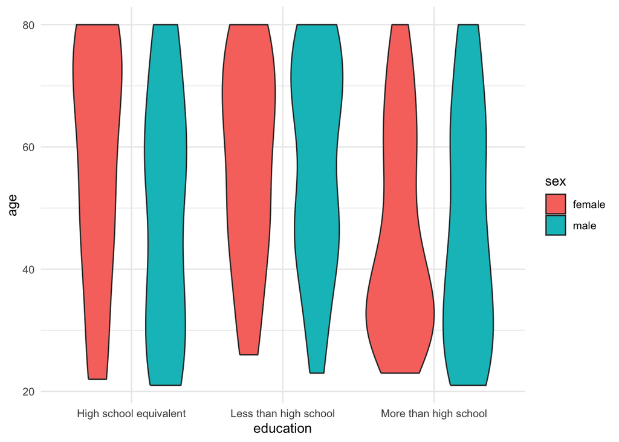

```r
dd_plot <- demographic_data |>
  ggplot(aes(x=education, y=age, fill=sex))+
  geom_violin()+
  theme_minimal()
dd_plot
```

Relatively, there are more men going to high school than women, for less than and more that high school, the number are pretty close.  
For both man and women, the age lies averagely for high school equivalent. There are less young energy(<30) for less than high school, while for more than high school, the condition is exactly the opposite.

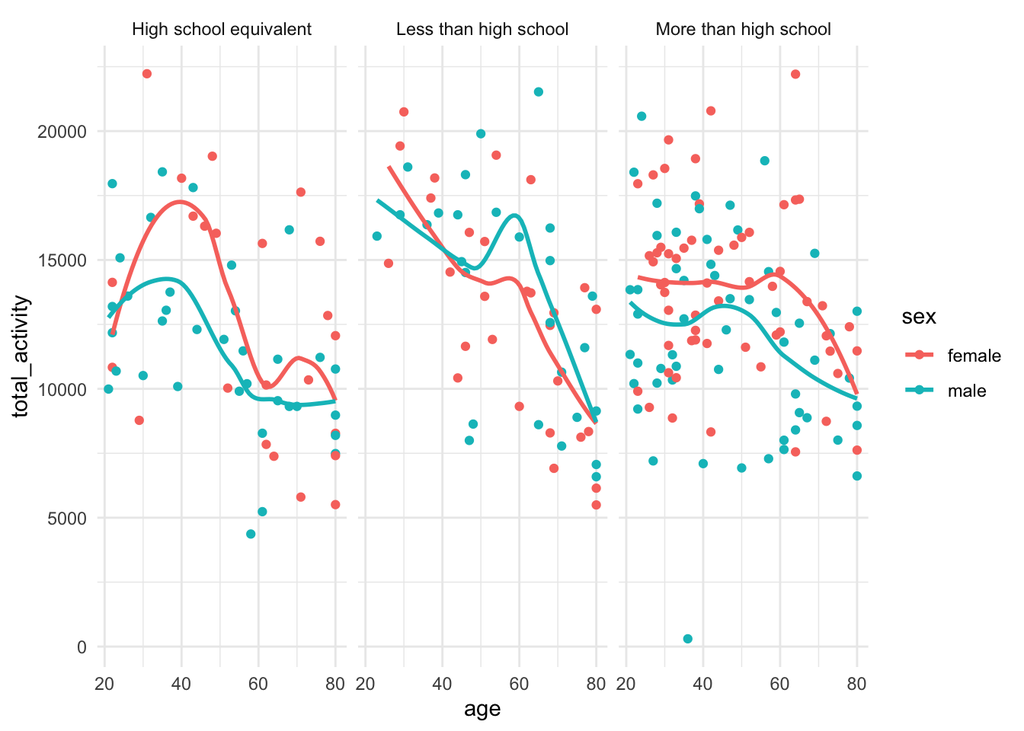

```r
total_activity_data <-
  accelerometer_data |>
  rowwise() |>
  mutate(total_activity=sum(c_across(min1:min1440),na.rm=TRUE)) |>
  select(seqn, total_activity) |>
  left_join(demographic_data,by='seqn') |>
  na.omit()

ggplot(total_activity_data, aes(x=age, y=total_activity, color=sex))+
  geom_point()+
  geom_smooth(method = 'loess', se=FALSE)+
  facet_wrap(.~education)+
  theme_minimal()
```

We can see from the plots that no matter what education level for both man and woman, their total activital tend to get smaller as the age goes up.

[figure not shown]

```r
acc_data <- accelerometer_data |>
  pivot_longer(cols = starts_with('min'),
               names_to = 'minutes',
               values_to = 'activity') |>
  left_join(demographic_data,by='seqn') |>
  na.omit()
ggplot(acc_data, aes(x=minutes,y=activity,color=sex))+
         geom_line()+
         geom_smooth(se=FALSE)+
         facet_wrap(.~education)+
         theme_minimal()
```

Q3.

```r
Jan_2020_Citi <- read_csv("citibike/Jan 2020 Citi.csv", na = c('NA', ' ', '.')) |>
  drop_na() |>
  janitor::clean_names() |>
  mutate(year=2020, month='January')
July_2020_Citi <- read_csv("citibike/July 2020 Citi.csv",na = c('NA', ' ', '.')) |>
  drop_na() |>
  janitor::clean_names() |>
  mutate(year=2020, month='July')
Jan_2024_Citi <- read_csv("citibike/Jan 2024 Citi.csv",na = c('NA', ' ', '.')) |>
  drop_na() |>
  janitor::clean_names() |>
  mutate(year=2024, month='January')
July_2024_Citi <- read_csv("citibike/July 2024 Citi.csv",na = c('NA', ' ', '.')) |>
  drop_na() |>
  janitor::clean_names() |>
  mutate(year=2024, month='July')
Q3_data_all <- bind_rows(Jan_2020_Citi,July_2020_Citi,Jan_2024_Citi,July_2024_Citi) |>
  janitor::clean_names()
```

The datasets show the data of bike usage.

```r
total_rides_data <- Q3_data_all |>
  group_by(year,month,member_casual) |>
  summarise(total_rides=n(), .groups = 'drop')
```

```r
top_5_starting_station_July2024 <- July_2024_Citi |>
  group_by(start_station_name) |>
  summarise(total_rides=n(),.groups = 'drop') |>
  arrange(desc(total_rides)) |>
  slice(1:5)
```

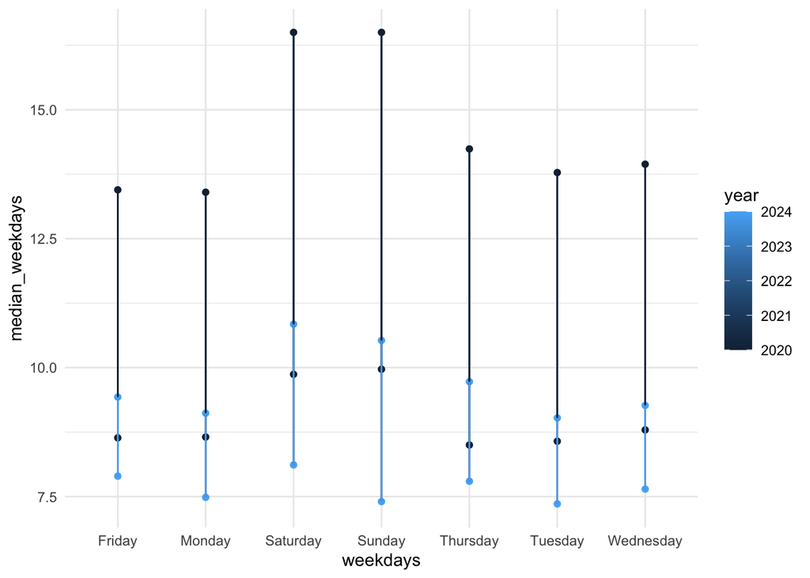

```r
Q3_data_all_median <- Q3_data_all |>
  group_by(year, month, weekdays) |>
  summarise(median_weekdays=median(duration),.groups = 'drop')

ggplot(Q3_data_all_median,
       aes(x=weekdays, y=median_weekdays,
           color=year)) +
  geom_point()+
  geom_line()+
  theme_minimal()
```

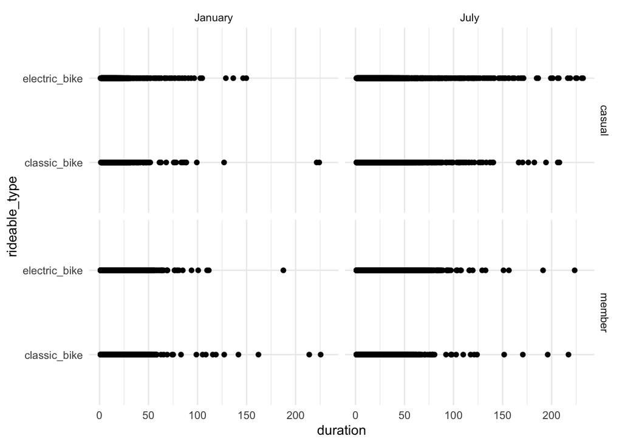

```r
data_2024 <- Q3_data_all |>
  filter(year==2024)

ggplot(data_2024,aes(x=duration, y=rideable_type))+
  geom_point()+
  facet_grid(member_casual~month) +
  theme_minimal()
```